## Beaver Stream Metabolism

We estimated stream metabolic fluxes from 6 streams both 100 m upstream and 5 m downstream of beaver dams. Below is a discussion of the estimates. At each site, if there were multiple sensor deployments, we grouped these into a single model run in order to improve estimation of K600. We ran the model with normal pooling of K600 because there was minimal variation in discharge within a given site, so it is reasonable to expect K600 to be somewhat constant between days.

### Metabolism estimates:

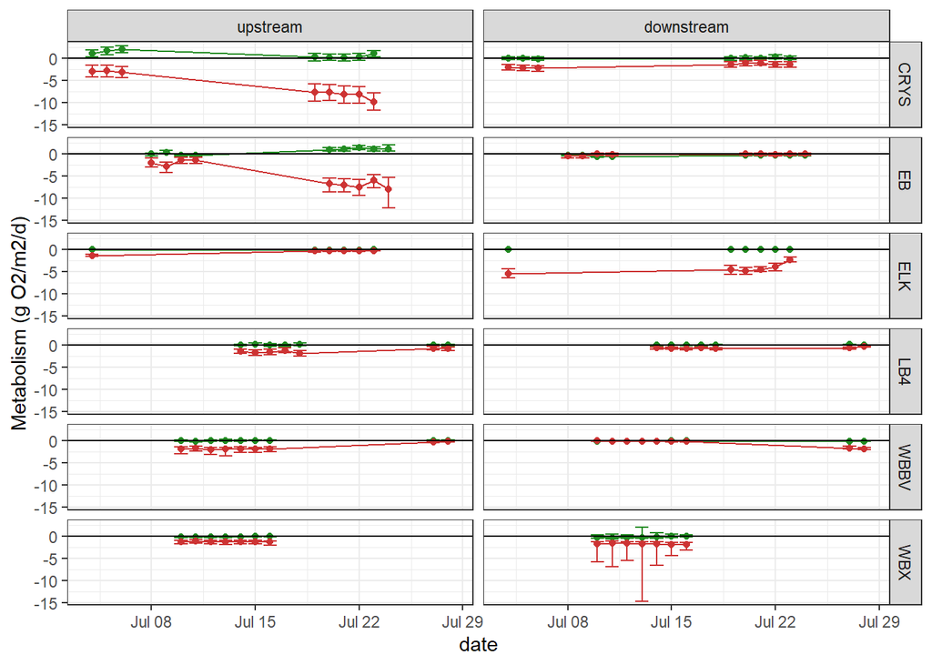

Many of these estimates for GPP are very close to Zero or even negative. This could have something to do with the large temperature swings at these sites - I’ve noticed that many of the sites have peak oxygen concentrations early in the morning when stream temperature is the lowest. This indicates that the physical control on oxygen solubility is a larger control than that of in stream productivity, which would result in a peak in oxygen later in the day, somewhat after peak solar insolation.

Here is an example of one of these sites:

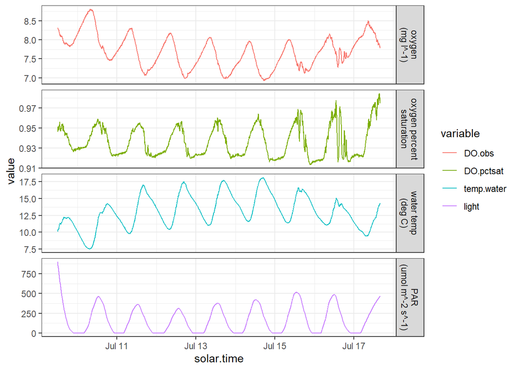

This makes sense, especially at the sites just downstream of the beaver dams. I would expect that water that has recently traveled over a spillway would be in close to physical equilibrium with the atmosphere, with little biological signal left to measure. We do see peaks in DO percent saturation not too long after solar noon, which likely means there is some biological signal. It’s just not very large, only about 2-4% change in DO percent sat over the course of the whole day.

This problem applies to about half of the measurements of GPP:

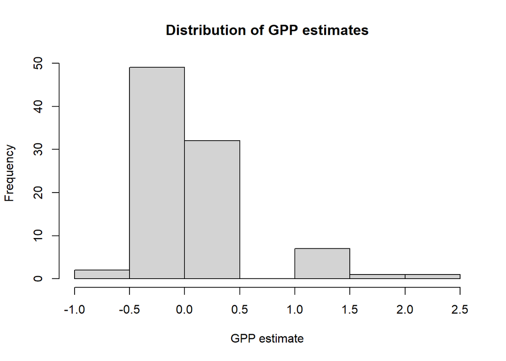

## Model fit assesment

### K600 by ER relationships:

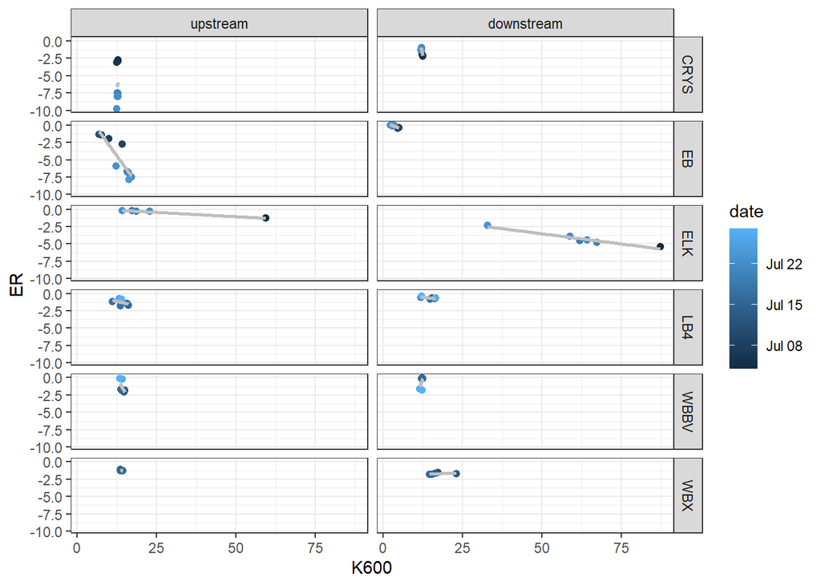

### Parameter Convergence

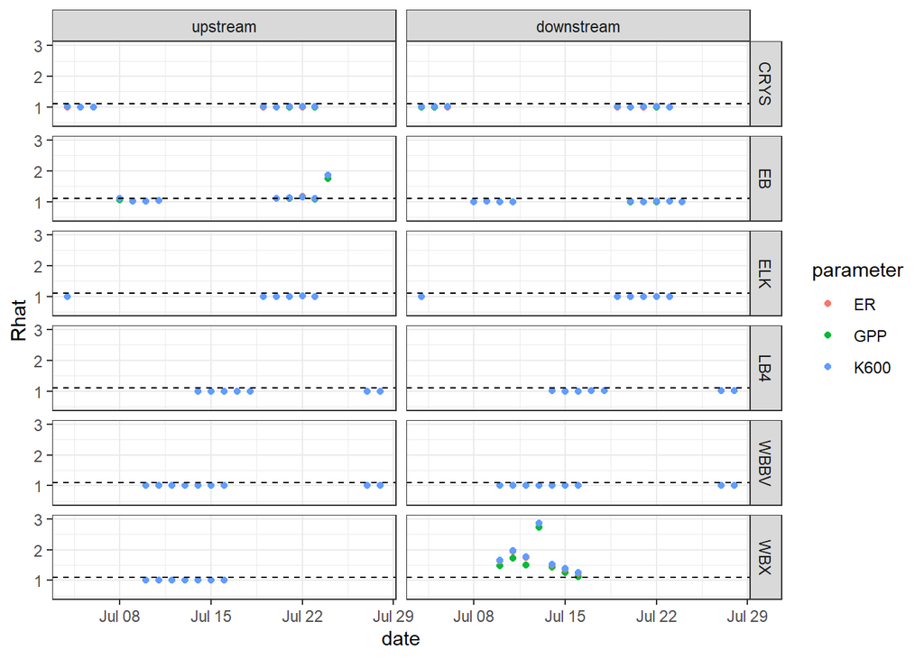

### Model reruns for ELK sites:

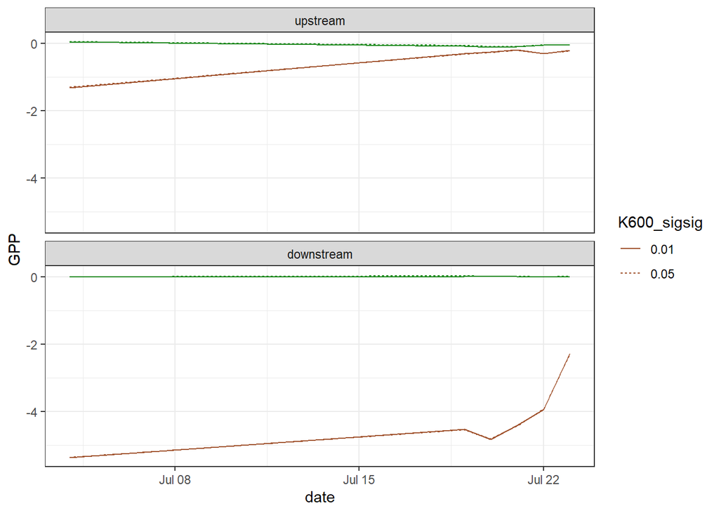

The change in prior has not resulted in a change in metabolism estimates.

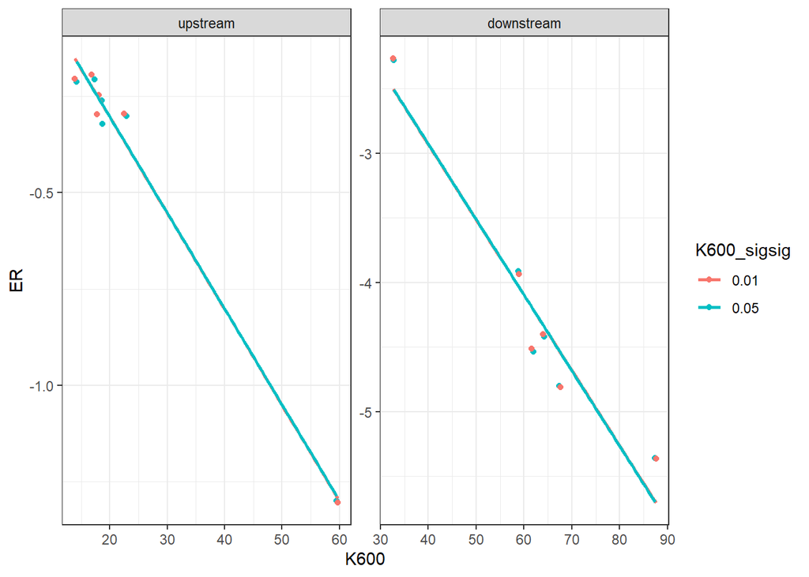

Similarly, we see virtually no change in estimates of K600 and the high correlation between K600 and ER remains. This means that the model is refusing to acknowledge our prior (which constrains values of K600 to ~1% between days). The way you would have to model this site is with a fixed K600 value based on measured gas exchange rates.

### Model reruns for EB upstream and WBX downstream sites:

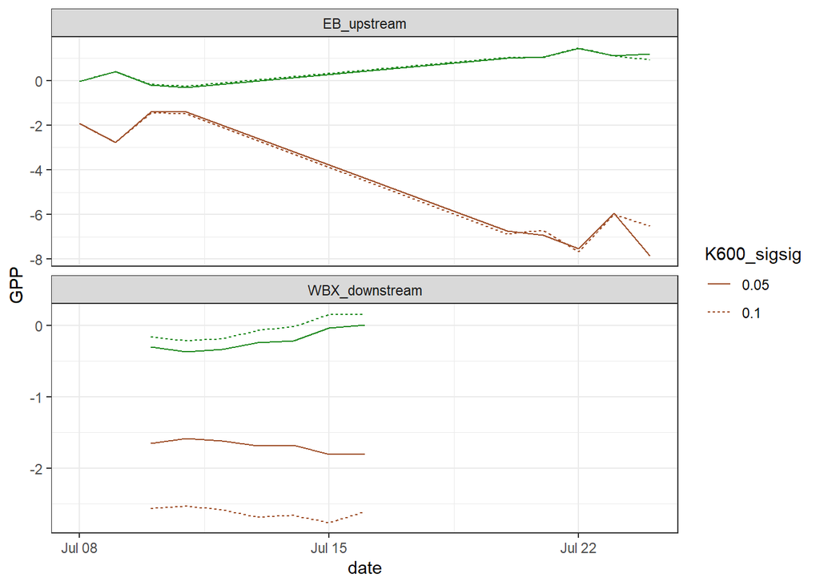

Here, metabolism estimates at EB_upstream have not shifted in response to the new prior but at WBX_downstream, the have increased.

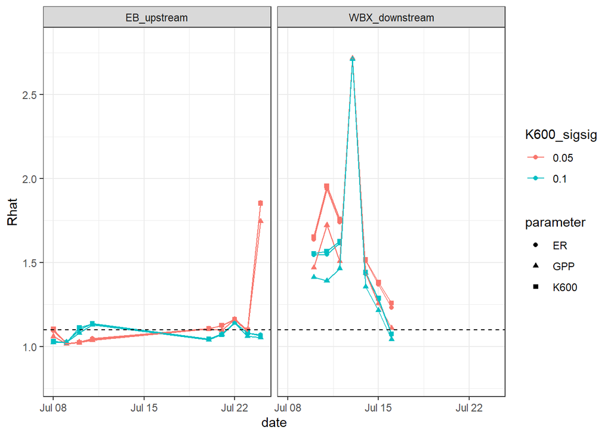

Slight improvement, but not much change in chain convergence measured by Rhat other than on the final day for the EB_upstream site. We can try one more time, loosening the prior on $\sigma_{K600}$

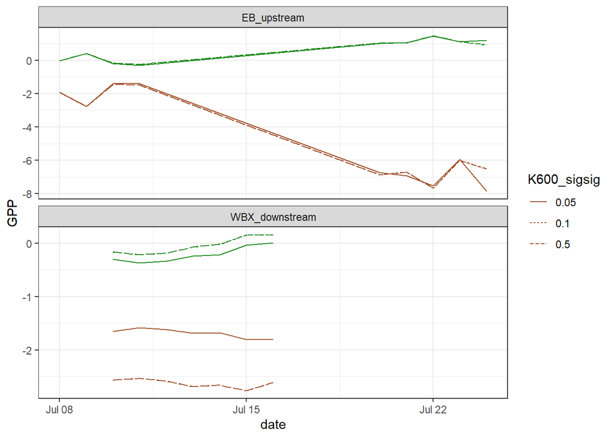

There is no further change in the metabolism estimates by running the model with $\sigma_{K600} = 0.5$

### Compile the best fits for each site

For all sites except EB upstream and WBX downstream, I have kept the estimates from the model with the prior on $\sigma_{K600} = 0.05$. For those two sites, loosening the prior to 0.1 seemed to improve Rhats and fits a bit, so I have selected those models.